# ÉTUDE GÉNÉRALISÉE DE LA SOUS-NUTRITION DANS LE MONDE

*Par Bertrand Delorme, Data Analyst*

**INTRODUCTION:** Notre projet traitera de la faim dans le monde. Nous objecterons d'analyser, de cibler et de comprendre les différentes causes et besoins de ce fléau qui touche encore aujourd'hui une part importante de la population mondiale. Notre fil conducteur sera donc la problématique et le plan suivants:

**Quelles sont les conditions, les causes et les enjeux de la faim dans le monde?**

- Mission 1: Nous procéderons dans une premier temps à la récolte des données et à une présentation graphique de chaque variable étudiée.
- Mission 2: Nous objecterons ensuite de mettre les variables récoltées en relation et d'expliquer les causes de la faim dans le monde.
- Mission 3: Nous chercherons ensuite à regrouper les pays étudiés selon les variables présentées et d'en étudier les différents types de besoins.
- Mission 4: Enfin, nous présenterons des axes d'amélioration en vue de lutter contre la faim dans le monde à différents niveaux.

**Les données que nous traiterons sont issues de la [Food and Agriculture Organization Corporate Statistical Database](http://www.fao.org/faostat/fr/#data), branche de l'ONU, tirées des bilans alimentaires présents sur leur site officiel. Au cours de ce projet, nous nous appuierons sur les chiffres de 2017 pour avoir une estimation de la situation actuelle mondiale. Nous nous concentrerons sur les états dont la FAO recense des personnes en sous-nutrition, en considérant ce taux comme nul pour les états dont la FAO n'en recense pas afin de mieux traîter nos données.**

**Sommaire**

**Un code de couleurs à été attribué aux différentes parties à titre de repère.**

Mission 1 : Récolte des données et

mise au point sur la situation actuelle

**I. État actuel de la sous-nutrition dans le monde**

I.1. Population et sous-nutrition

I.2. Urgence alimentaire: Deux types de problème

I.3. Prévisions de la sous-nutrition d'ici 2050

**II. Disposition et nécessité alimentaire**

II.1. Besoins nutritionnels du corps humain et nécessité mondiale

II.2. Disponibilité alimentaire mondiale

II.3. Disponibilité alimentaire destinée à l'homme

**III. Potentiel alimentaire**

III.1. Définitions et standard

III.2. Potentiel seuil

**IV. Finalisation du DataFrame principal**

IV.1. Disponibilité alimentaire synthétisée

IV.2. PIB par habitant

IV.3. Récapitulatif du DataFrame world

Mission 2 : Analyse des variables et

explications de la sous-nutrition

**I. Analyse des corrélations**

I.1. Matrice des corrélations

I.2. Cercle des corrélations

**II. Analyse de la variance de la sous-nutrition**

II.1. Préparatifs des analyses

II.2. Variance de la sous-nutrition

II.3. Variance du pourcentage de la sous-nutrition

Mission 3 : Ciblage des zones dans

le besoin alimentaire

**I. Classification hiérarchique des états**

I.1. Dendrogramme

I.2. Clustering et projection sur le 1er plan factoriel

I.3. Description des clusters

**II. Analyses graphiques interclusters**

II.1. Fonctions préliminaires

II.2. Représentations des clusters à l'échelle mondiale

II.3. Des potentiels alimentaires irréguliers

II.4. Inégalités économiques

**III. Observations approfondies**

III.1. Besoins alimentaires

III.2. L'Inde et la Chine

III.3. Des pays dans l'urgence alimentaire

Mission 4 : Axes de lutte

contre la faim dans le monde

**I. Utilisation de la disponibilité alimentaire**

I.1. Remaniement du DataFrame et nouvelles variables

I.2. Ajustement de constantes et fonction de la barre nutritive

I.3. Taux d'utilisation de la disponibilité alimentaire

**II. Pertes alimentaires**

II.1. Potentiel alimentaire pouvant être libéré dans le monde

II.2. Ciblage géographique

II.3. Des pays autosuffisants sans les pertes

**III. Autres libérations alimentaires**

III.1. Nourriture pour animaux

III.2. Autres utilisations

III.3. Taux d'exportations

**IV. Conclusion**

### Nous importons dans un premier temps l'ensemble des librairies nécessaires pour l'ensemble du projet.

```python
import pandas as pd
import numpy as np
from functions import *
import os

import matplotlib.pyplot as plt
from matplotlib.pyplot import figure
from matplotlib.pylab import arange, plot
import matplotlib as mpl
from pylab import *
import matplotlib.patches as mpatches
from collections import Counter
from termcolor import colored

import statsmodels.api as sm
import statsmodels.formula.api as smf
from statsmodels.formula.api import ols
from statsmodels.stats.outliers_influence import variance_inflation_factor
from statsmodels.tsa.stattools import adfuller, kpss, acf, pacf
from statsmodels.stats.diagnostic import acorr_ljungbox
from statsmodels.tsa.seasonal import seasonal_decompose
from statsmodels.graphics.tsaplots import plot_acf
from statsmodels.tsa.statespace.sarimax import*
from statsmodels.tsa.api import ExponentialSmoothing

from sklearn import decomposition, preprocessing
from sklearn.preprocessing import StandardScaler
sc = StandardScaler()
from sklearn.cluster import KMeans
from sklearn.metrics import make_scorer, r2_score
from sklearn.svm import SVC
import scipy
import scipy.stats as st
from scipy.stats import t, shapiro, ks_2samp
from scipy.cluster.hierarchy import dendrogram, linkage, fcluster

# La fonction dim() nous permettra de définir à chaque fois les dimensions des figures que l'on affichera:
def dim(x, y): return(plt.figure(figsize=(x, y)))

# Outils de génération des cartes du monde colorisées:
import cartopy
import cartopy.io.shapereader as shpreader
import cartopy.crs as ccrs
shpfilename = shpreader.natural_earth(resolution="110m", category="cultural", name="admin_0_countries")
reader = shpreader.Reader(shpfilename)
from world_cartography import *

from IPython.core.display import HTML
import warnings
warnings.filterwarnings('ignore')
HTML("""<style> .output_png {display: table-cell; text-align: center; vertical-align: middle} </style>""")
```

Vous trouverez également ici [l'annexe](https://bertrand4.github.io/world_maker_project/WM_packages) des modules importés, notamment la description des fonctions utilisées pour générer les cartes mondiales à venir.

Vous noterez que j'ai tendance à "condenser" mes lignes de codes, ceci pour avoir une meilleure visibilité globale de mes cellules. Néanmoins, si cela vous pose problème pour la lecture, je vous invite à vous rediriger vers [ce script](https://bertrand4.github.io/world_maker_project/world_maker_project_sp).

# Mission 1: Récolte des données et mise au point sur la situation actuelles

# I. État actuel de la sous-nutrition dans le monde

## *I.1. Population et sous-nutrition*

**Sur les 195 états du monde reconnus par l'ONU, seuls 166 seront pris en compte dans notre étude. Certaines des données que nous étudierons n'ont pas été relevées par la FAO pour les pays restants, c'est pourquoi nous nous limiterons notre étude aux 166 pays dont nous disposons de valeurs certifiées et en écarterons les autres pour un meilleur ajustement des résultats à venir.**

Nous présentons donc notre DataFrame principal **world**, où seront collectées les données relevées sur la FAO, qui présente pour le moment les variables:

- *population* : Le nombre d'habitants par pays.
- *undernourished* : Le nombre d'habitants en sous-nutrition dans un pays donné.
- *und_percentage* : Le pourcentage de la population en sous-nutrition au sein du pays donné.

```python
world = pd.read_csv("data/projet_R/W/world.csv").set_index("country")

und=world.loc[world["undernourished"]!=0] # Le DataFrame "und" ne contiendra que les pays recensant la sous-nutrition.

print("Aujourd'hui, %s états sur %d recensent une partie de la population la sous-nutrition." %(len(und), len(world)))
world
```

```
Aujourd'hui, 118 états sur 166 recensent une partie de la population la sous-nutrition.
```

| country | population | undernourished | und_percentage |
| --- | --- | --- | --- |
| Afghanistan | 36296110.0 | 10600000.0 | 29.20 |
| Afrique du Sud | 57009760.0 | 3500000.0 | 6.14 |
| Albanie | 2884170.0 | 200000.0 | 6.93 |
| Algérie | 41389190.0 | 1600000.0 | 3.87 |
| Allemagne | 82658410.0 | 0.0 | 0.00 |
| ... | ... | ... | ... |
| Émirats arabes unis | 9487200.0 | 200000.0 | 2.11 |
| Équateur | 16785360.0 | 1300000.0 | 7.74 |
| États-Unis | 325084760.0 | 0.0 | 0.00 |
| Éthiopie | 106399920.0 | 21600000.0 | 20.30 |
| Îles Salomon | 636040.0 | 57000.0 | 8.96 |

166 rows × 3 columns

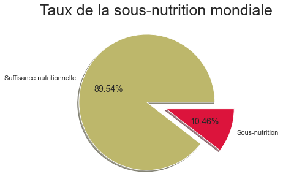

```python
POPULATION = sum(world["population"]) # Le nombre d'êtres humains sur Terre en 2017.
SSN = world["undernourished"].sum() # Nombre d'individus sur Terre en sous-nutrition.

dim(5, 5) ; mpl.rcParams['font.size'] = 14

plt.pie([POPULATION-SSN, SSN],
        labels = ["Suffisance nutritionnelle", "Sous-nutrition"],
        colors = ["darkkhaki", "crimson"],
        explode = [0, 0.3], autopct = '%1.2f%%', shadow = True)

plt.title("Taux de la sous-nutrition mondiale", fontsize = 25)
plt.ylabel("")
plt.axis("equal")
plt.show()
```

Ce graphique représente tout simplement le taux de la population mondiale en sous-nutrition, où l'on constate qu'environ **10,5%** du monde est encore aujourd'hui concernée par la famine. **La sous-nutrition concerne donc encore aujourd'hui plus d'un être humain sur 10.**

Un des objectifs de ce projet est de cibler les zones géographiques où l'on recense la famine, et d'en étudier les conditions et autres critères, c'est pourquoi nous allons générer une première carte du monde colorisée selon les différents pourcentages de la population locale d'un pays souffrant de la sous-nutrition.

**Par défaut, sur chaque carte que nous tracerons, les pays dont nous ne disposions pas des données nécessaires à leur études, et donc écartés du projet, resteront en blanc et ne seront pas à prendre en compte pour une quelconque interprétation. Ces cartes sont générés grâce au module cartopy importé en introduction, ainsi qu'à la fonction cartography() définie en [annexe](https://bertrand4.github.io/world_maker_project/WM_packages) du projet.**

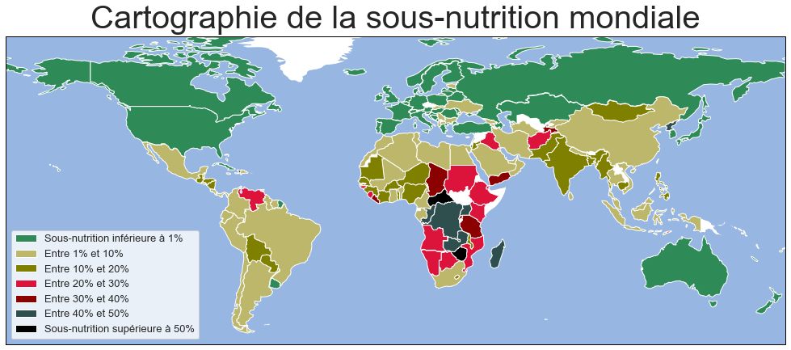

```python
def Sn(a, b):
    return(mapzone( world.loc[(world["und_percentage"]>=a) & (world["und_percentage"]<b)] ))

SN1, SN2, SN3, SN4, SN5, SN6, SN7 = Sn(0, 1), Sn(1, 10), Sn(10, 20), Sn(20, 30), Sn(30, 40), Sn(40, 50), Sn(50, 100)

palette = ["seagreen", "darkkhaki", "olive", "crimson", "darkred", "darkslategray", "black"]

dim(22, 7)

ax = plt.axes(projection=ccrs.PlateCarree())
ax = carte(ax)

cartography([SN1, SN2, SN3, SN4, SN5, SN6, SN7], palette, ax)

plt.legend(legendes(palette), ["Sous-nutrition inférieure à 1%"] + ["Entre 1% et 10%"] +
                              ["Entre {0}% et {1}%".format(i, i+10) for i in range(10, 41, 10)] +
                              ["Sous-nutrition supérieure à 50%"],  loc="lower left", fontsize=13)

plt.title("Cartographie de la sous-nutrition mondiale", fontsize=40, pad=10)
plt.show()
```

On retrouve bien le clivage géographique entre les pays développés et autosuffisants majoritairement au Nord, et les pays en voie de développement ou sous-développés au Sud où l'on relève la sous-nutrition. Les graves problèmes de famine en Afrique apparaissent clairement sur cette carte, mais observons cependant que l'on recense la sous-nutrition dans certains pays pourtant bien développés tels que le Mexique ou encore l'Estonie. Cet aspect sera notamment approfondi en mission 3 lorsque nous décrirons les différents critères des zones de sous-nutrition.

## *I.2. Urgence alimentaire: Deux types de problème*

Au court de ce projet, nous allons nous confronter à deux critères plus ou moins liés de pays en difficulté:

- **Les pays recensants le plus d'êtres humains en sous-nutrition.**
- **Les pays présentant les plus forts pourcentages de la population locale en sous-nutrition.**

Nous présentons ci-dessous les 15 pays les plus enclins à chacun de ces deux critères.

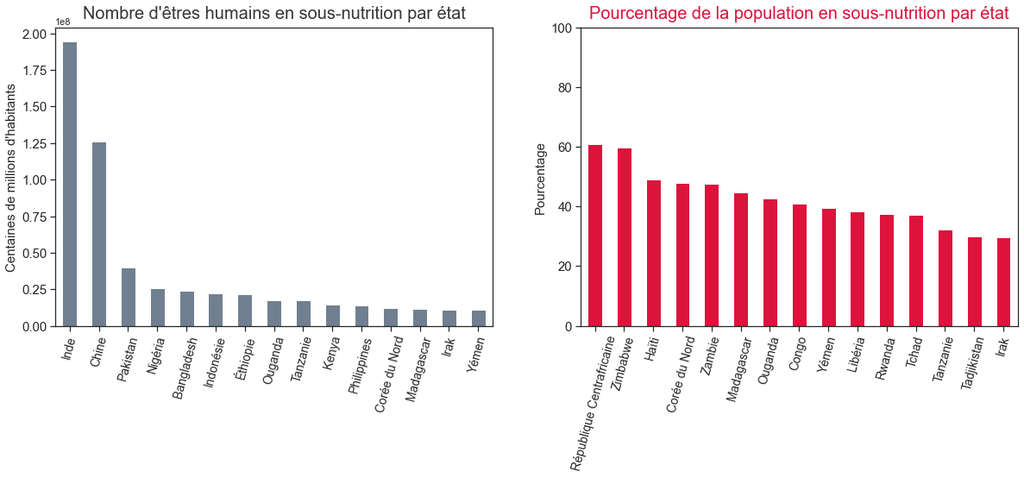

```python
top15_qua=world.sort_values("undernourished", ascending=False).head(15)
top15_per=world.sort_values("und_percentage", ascending=False).head(15)

dim(20, 14)

plt.subplot(2, 2, 1)
top15_qua["undernourished"].plot(kind="bar", color="slategray")
plt.title("Nombre d'êtres humains en sous-nutrition par état", fontsize=20, color="#393838", pad=10)
plt.xticks(fontsize=14, rotation=75)
plt.xlabel("")
plt.yticks(fontsize=15)
plt.ylabel("Centaines de millions d'habitants", fontsize=15)

plt.subplot(2, 2, 2)
top15_per["und_percentage"].plot(kind="bar", color="crimson")
plt.title("Pourcentage de la population en sous-nutrition par état", fontsize=20, color="crimson", pad=10)
plt.xlabel(""), plt.ylim(0,100)
plt.xticks(fontsize=14, rotation=75)
plt.xlabel("")
plt.yticks(fontsize=15)
plt.ylabel("Pourcentage", fontsize=15)

plt.show()
```

L'Asie couvre à elle seule plus de 58% de la population mondiale. C'est sur ce continent que l'on relève le plus d'êtres humains sous-alimentés comme le montre le premier histogramme avec près de 200 millions et 125 millions d'individus en sous-nutrition respectivement en Inde et en Chine, ces deux pays étant les plus peuplés du monde avec respectivement 1,353 et 1,393 milliards d'habitants.

## *I.3. Prévisions de la sous-nutrition d'ici 2050*

Chaque année, en moyenne, environ 800 millions d'êtres humains souffrent de famine. En relevant sur le site de la FAO les données de la sous-nutrition dans le monde jusqu'à aujourd'hui, on peut établir un graphique représentant l'évolution du nombre de personnes sous-alimentées depuis 1950. Un modèle de Holt-Winters peut nous donner une idées de la prédiction de la sous-nutrition d'ici 2050 en se basant sur les chiffres actuels.

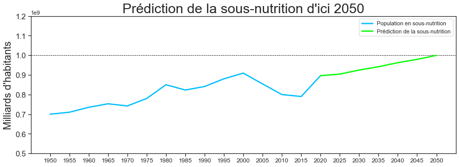

```python
undernourishment=pd.read_csv("data/projet_R/evo.csv").set_index("year")

und_pred=pd.Series(ExponentialSmoothing(np.asarray(undernourishment["undernourished"]), seasonal_periods=2,
                                          trend="add", seasonal="add").fit().forecast(6),
                   index=range(2025, 2051, 5))

und_pred[2020]=undernourishment.loc[2020, "undernourished"]
und_pred=und_pred.sort_index()

dim(15, 5)
plt.axhline(10**9, linestyle="--", color="black", linewidth=0.8)

plt.plot(undernourishment["undernourished"],
         label="Population en sous-nutrition",
         color="deepskyblue", linewidth=2.5)

plt.plot(und_pred,
         label="Prédiction de la sous-nutrition",
         color="lime", linewidth=2.5)

plt.title("Prédiction de la sous-nutrition d'ici 2050", fontsize=27)
plt.ylabel("Milliards d'habitants", fontsize=20)
plt.ylim(500000000, 1200000000)
plt.yticks(fontsize=15)
plt.xticks(range(1950, 2051, 5))
plt.xticks(fontsize=12)
plt.legend()
plt.show()
```

Cette prédiction montre que si l'on ne fait rien, nous sommes susceptibles de dépasser le milliard d'êtres humains sur terre en sous-nutrition d'ici 30 ans. L'objectif de ce projet étant de proposer des solutions à la non-réalisation de cette prédiction, nous commencerons par un rappel sur les besoins nutritionnels journaliers moyens d'un être humain et d'une mise au point sur la disponibilité alimentaire actuelle.

# II. Disposition et nécessité alimentaire

## *II.1. Besoins nutritionnels du corps humain et nécessité mondiale*

D'après le site [Futura Sciences](https://www.futura-sciences.com/), un être humain a besoin, en moyenne d'un apport journalier de 2250 kcalories, environ, soit un besoin de 821250 kcalories par an. D'après le site [e-santé](https://www.e-sante.fr/), un être humain a besoin, en moyenne d'un apport journalier de 0,055 kg, environ, soit un besoin de 20,075 kg par an. Sachant cela, en tenant compte de la population mondiale, on peut estimer le nombre de kilocalories ainsi que le nombre de kg de protéines nécessaires dans la disponibilité alimentaire mondiale afin de nourrir le monde entier.

```python
KILO_CAL = 821250 # Quantité annuelle moyenne en kilocalorie nécessaire à un être humain.
KILO_PROT = 20.075 # Quantité annuelle moyenne de kilogrammes de protéines nécessaire à un être humain.

KCAL_REQUIREMENT = POPULATION * KILO_CAL # Le nombre de kilocalories nécessaires pour nourrir la Terre entière.
PROT_REQUIREMENT = POPULATION * KILO_PROT # Le nombre de kilogrammes de protéines nécessaire pour nourrir la Terre entière.

print("En 2017, on compte %s d'êtres humains, ce qui demande la disponibilité alimentaire annuelle mondiale de:" %POPULATION)
print("- %e kilocalories." %KCAL_REQUIREMENT) ; print("- %e kilogrammes de protéines." %PROT_REQUIREMENT)
```

```
En 2017, on compte 7319227920.0 d'êtres humains, ce qui demande la disponibilité alimentaire annuelle mondiale de:
- 6.010916e+15 kilocalories.
- 1.469335e+11 kilogrammes de protéines.
```

## *II.2. Disponibilité alimentaire mondiale*

**À l'échelle mondiale, disposons-nous de ressources et de productions suffisante pour nourrir le monde entier?** C'est bien sûr la première question à se poser lorsque l'on veut tenter de libérer le monde de la faim. C'est pourquoi nous allons comparer dans cette sous-partie la disponibilité alimentaire mondiale et la disponibilité alimentaire nécessaire pour nourrir le monde entier. Commençons par ajouter à **world** les deux variables suivantes tirées de la FAO pour un pays donné:

- *domestic_supply_kcal* : La disponibilité intérieure annuelle totale en terme de kilocalories.
- *domestic_supply_kgproteine* : La disponibilité intérieure annuelle totale en terme de kilogrammes de protéines.

```python
supply = pd.read_csv("data/projet_R/W/supply.csv").set_index("country")
world = world.join(supply)
world.head(5)
```

| country | population | undernourished | und_percentage | domestic_supply_kcal | domestic_supply_kgproteine |
| --- | --- | --- | --- | --- | --- |
| Afghanistan | 36296110.0 | 10600000.0 | 29.20 | 3.180962e+13 | 8.481271e+08 |
| Afrique du Sud | 57009760.0 | 3500000.0 | 6.14 | 9.544646e+13 | 2.774365e+09 |
| Albanie | 2884170.0 | 200000.0 | 6.93 | 5.849801e+12 | 1.810956e+08 |
| Algérie | 41389190.0 | 1600000.0 | 3.87 | 7.946168e+13 | 2.048977e+09 |
| Allemagne | 82658410.0 | 0.0 | 0.00 | 3.676455e+14 | 7.135272e+09 |

Comparons alors sur un histogramme la disponibilité alimentaire mondiale réelle et la disponibilité alimentaire nécessaire pour nourrir le monde entier.

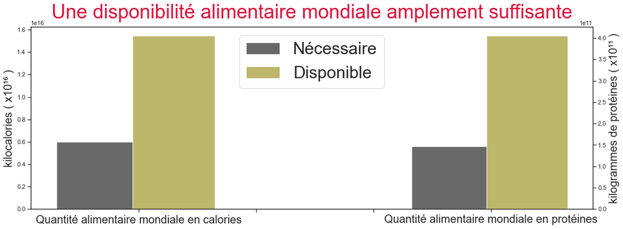

```python
dim(18, 6)

plt.bar(0.7, KCAL_REQUIREMENT, color="dimgrey", label="Nécessaire")
plt.bar(1.3, world["domestic_supply_kcal"].sum(), width=0.7, color="darkkhaki", label="Disponible")
plt.ylabel("kilocalories ( x10¹⁶ )", fontsize=20)
plt.xticks(fontsize=20)

plt.gca().twinx()
plt.bar(3.7, PROT_REQUIREMENT, color="dimgrey", label="Nécessaire")
plt.bar(4.3, world["domestic_supply_kgproteine"].sum(), width=0.7, color="darkkhaki", label="Disponible")
plt.ylabel("kilogrammes de protéines ( x10¹¹ )", fontsize=20)

plt.title("Une disponibilité alimentaire mondiale amplement suffisante", fontsize=35, color="crimson", pad=15)
plt.xticks(range(0, 5), ["","Quantité alimentaire mondiale en calories","",
                         "","Quantité alimentaire mondiale en protéines"])
plt.legend(loc="upper center", fontsize=30)
plt.show()
```

Tout l'intérêt du projet est ici: **le monde est excédentaire que ce soit en termes de calories ou en terme de protéines**. Sachant cela, **il est indéniable qu'une solution pour libérer le monde de la faim existe**. Bien entendu, malheureusement, la famine est un fléau que l'on pourra difficilement inhiber totalement en dépit des conflits politiques actuels ou à venir, mais nous montrerons que certaines réorganisations pourraient tout de même réduire fortement le nombre d'êtres humains en sous-nutrition.

## *II.3. Disponibilité alimentaire destinée à l'homme*

L'ensemble de la disponibilité alimentaire n'est pas uniquement consacrée à la nourriture. Nous pouvons relever par exemple la producion alimentaire destinée aux animaux, les pertes, les semences... C'est pourquoi nous ajoutons maintenant à **world** les deux variables suivantes pour un pays donné:

- *food_supply_kcal* : La disponibilité intérieure annuelle totale en nourriture en terme de kilocalories.
- *food_supply_kgproteine* : La disponibilité intérieure annuelle totale en nourriture en terme de kilogrammes de protéines.

Attention à ne pas confondre ces nouvelles variables avec les deux précédentes!

```python
food=pd.read_csv("data/projet_R/W/food.csv").set_index("country")
world=world.join(food)
world.head(5)
```

| country | population | undernourished | und_percentage | domestic_supply_kcal | domestic_supply_kgproteine | food_supply_kcal | food_supply_kgproteine |
| --- | --- | --- | --- | --- | --- | --- | --- |
| Afghanistan | 36296110.0 | 10600000.0 | 29.20 | 3.180962e+13 | 8.481271e+08 | 2.645642e+13 | 7.165887e+08 |
| Afrique du Sud | 57009760.0 | 3500000.0 | 6.14 | 9.544646e+13 | 2.774365e+09 | 6.215518e+13 | 1.734602e+09 |
| Albanie | 2884170.0 | 200000.0 | 6.93 | 5.849801e+12 | 1.810956e+08 | 3.579255e+12 | 1.258003e+08 |
| Algérie | 41389190.0 | 1600000.0 | 3.87 | 7.946168e+13 | 2.048977e+09 | 5.053310e+13 | 1.402690e+09 |
| Allemagne | 82658410.0 | 0.0 | 0.00 | 3.676455e+14 | 7.135272e+09 | 1.073762e+14 | 3.139825e+09 |

Nous avons vu que la disponibilité alimentaire pouvait nourrir plus du double de la population mondiale. Si l'on se limite à la disponibilité alimentaire dédiée à la nourriture, nous observerons des résultats tout aussi révélateurs.

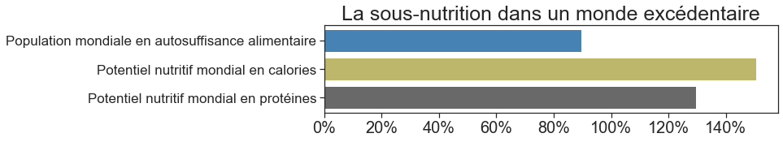

```python
a=100*world["food_supply_kcal"].sum()/KCAL_REQUIREMENT
b=100*world["food_supply_kgproteine"].sum()/PROT_REQUIREMENT
c=100*(POPULATION-SSN)/POPULATION

dim(10, 2)

plt.barh([1, 2, 3], [a, b, c],
         color=["dimgrey", "darkkhaki", "steelblue"])

plt.yticks([1, 2, 3], ["Potentiel nutritif mondial en protéines",
                       "Potentiel nutritif mondial en calories",
                       "Population mondiale en autosuffisance alimentaire"], fontsize=17)
plt.xticks(range(0, 151, 20), ["{}%".format(i) for i in range(0, 151, 20)], fontsize=20)
plt.title("La sous-nutrition dans un monde excédentaire", fontsize=25)
plt.show()
```

Au bas mot, en ne tenant compte que de la disponibilité alimentaire destinée à la nourriture, nous disposons de quoi nourrir plus de 125% de la population mondiale, alors que près de 10,5% souffre de sous-nutrition. Il est évident que les relations internationales politiques et commerciales sont à l'origine de cette mauvaise répartition alimentaire, mais il est important d'affirmer que nous avons néanmoins, largement les capacités de nourrir le monde entier. Les pays en sous-nutrition ne sont pas tous nécessairement dans le "même besoin". Par exemple, certains nécessites un apport alimentaire plus riche en protéine malgré une autosuffisance en calories, d'autres inversement, etc... Mais nous pouvons relever que ces deux nouvelles variables sont sensiblement proportionnelles comme le montre le nuage suivant.

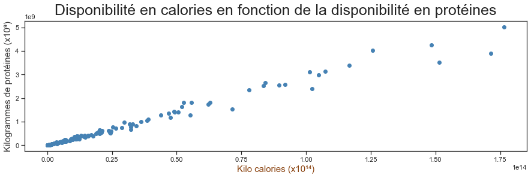

```python
# Nous retirons ces quelques outliers pour une meilleures visibilité :
df =  world.drop(index=["Chine", "Inde", "États-Unis", "Brésil", "Indonésie", "Russie"])

dim(15, 4)
plt.plot(df["food_supply_kcal"], df["food_supply_kgproteine"],
         "o", color="steelblue")

plt.title("Disponibilité en calories en fonction de la disponibilité en protéines", fontsize=25, pad=10)
plt.xlabel("Kilo calories (x10¹⁴)", color="saddlebrown", fontsize=15)
plt.ylabel("Kilogrammes de protéines (x10⁹)", color="#393838", fontsize=15)
plt.show()
```

Nous pouvons donc estimer une certaine corrélation entre ces deux types de disponibilité alimentaire. C'est pourquoi nous allons créer dans la partie suivante une nouvelle variable qui donnera un indice des besoins de ces deux dernières.

# III. Potentiel alimentaire

## *III.1. Définitions et standard*

Nous avons relevé jusqu'ici le nombre d'habitants dans chaque pays, la disponibilité intérieure alimentaire en terme de calories et de protéines ainsi que les besoins nutritionnels annuels du corps humain concernant ces deux unités d'énergie. Nous pouvons alors introduire deux nouvelles variables synthétiques dans **world** :

- *potentiel_calorie* : Qui nous renvoie le pourcentage de la population que le pays en question est en mesure de nourrir en terme de calories.
- *potentiel_proteine* : Qui nous renvoie le pourcentage de la population que le pays en question est en mesure de nourrir en termine de protéines.

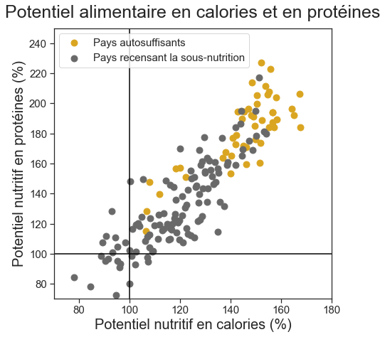

```python
world["potentiel_calorie"] = 100*world["food_supply_kcal"]/(world["population"]*KILO_CAL)
world["potentiel_proteine"] = 100*world["food_supply_kgproteine"]/(world["population"]*KILO_PROT)

aut = world.loc[world["undernourished"]==0]
und = world.loc[world["undernourished"]!=0]

fig, ax = plt.subplots(figsize=(7, 7))
plt.axhline(100, color="black") ; plt.axvline(100, color="black")

aut.plot.scatter(ax=ax, x="potentiel_calorie", y="potentiel_proteine",
                 s=80, color="goldenrod", fig=fig, label="Pays autosuffisants")

und.plot.scatter(ax=ax, x="potentiel_calorie", y="potentiel_proteine",
                 s=80, color="dimgrey", fig=fig, label="Pays recensant la sous-nutrition")

plt.title("Potentiel alimentaire en calories et en protéines", fontsize=25, pad=15)
plt.xticks(fontsize=15)
plt.yticks(fontsize=15)
plt.xlim(70, 180)
plt.ylim(70, 250)
plt.xlabel("Potentiel nutritif en calories (%)", fontsize=20)
plt.ylabel("Potentiel nutritif en protéines (%)", fontsize=20)
plt.legend(fontsize=15, loc="upper left")
plt.show()
```

Nous avons représenté sur ce graphique les états selon leur potentiel nutritif:

- Les pays situés dans la partie supérieure droite sont les pays dont le potentiel alimentaire intérieur serait suffisant pour nourrir la population locale.
- Dans la partie supérieure gauche, on y trouve les pays capables de nourrir leur population en terme de protéines mais pas en terme de calories.
- Inversement dans la partie inférieure droite.
- La partie inférieure gauche représente les pays dont les besoins sont des plus urgents, leur disponibilité intérieure ne leur permet pas de nourrir leur population, ni en protéines, ni en calories.

Nous pouvons nous demander s'il existe une corrélation entre chacun de ces deux types de manque et la position géographique des pays concernés, ce que nous allons visualiser sur la carte suivante, en considérant un potentiel alimentaire comme étant "insuffisant" sous le seuil de 110%.

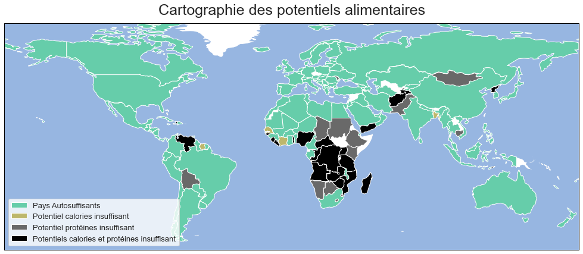

```python
P1 = mapzone(world.loc[(world["potentiel_calorie"]>110) & (world["potentiel_proteine"]>110)])
P2 = mapzone(world.loc[(world["potentiel_calorie"]>110) & (world["potentiel_proteine"]<=110)])
P3 = mapzone(world.loc[(world["potentiel_calorie"]<=110) & (world["potentiel_proteine"]>110)])
P4 = mapzone(world.loc[(world["potentiel_calorie"]<=110) & (world["potentiel_proteine"]<=110)])

palette = ["mediumaquamarine", "darkkhaki", "dimgray", "black"]

dim(22, 7)
ax = plt.axes(projection=ccrs.PlateCarree())
ax = carte(ax)
cartography([P1, P2, P3, P4], palette, ax)

plt.legend(legendes(palette), ["Pays Autosuffisants",
                               "Potentiel calories insuffisant",
                               "Potentiel protéines insuffisant",
                               "Potentiels calories et protéines insuffisant"],
           loc="lower left", fontsize=13)

plt.title("Cartographie des potentiels alimentaires", fontsize=25, pad=15)
plt.show()
```

## *III.2. Potentiel seuil*

Dans le cadre des analyses à venir, nous chercherons à tenir compte de chaque pays ayant un potentiel alimentaire insuffisant dans l'une des deux unités d'énergie étudiée. C'est pourquoi nous ajouterons à **world** la variable synthétique suivante:

- *potentiel* : Qui nous renvoie le minimum des deux variables précédentes, donc le pourcentage de la population que le pays en question est en mesure de nourrir en calories et en protéines.

C'est ce que nous appellerons **potentiel alimentaire** tout le long du projet.

```python
world["potentiel"]=world[["potentiel_calorie", "potentiel_proteine"]].min(axis=1)

world[["population", "und_percentage", "potentiel_calorie", "potentiel_proteine", "potentiel"]].head(5)
```

| country | population | und_percentage | potentiel_calorie | potentiel_proteine | potentiel |
| --- | --- | --- | --- | --- | --- |
| Afghanistan | 36296110.0 | 29.20 | 88.755556 | 98.345455 | 88.755556 |
| Afrique du Sud | 57009760.0 | 6.14 | 132.755556 | 151.563636 | 132.755556 |
| Albanie | 2884170.0 | 6.93 | 151.111111 | 217.272727 | 151.111111 |
| Algérie | 41389190.0 | 3.87 | 148.666667 | 168.818182 | 148.666667 |
| Allemagne | 82658410.0 | 0.00 | 158.177778 | 189.218182 | 158.177778 |

Il serait donc intéressant de visualiser l'ensemble des pays étudiés selon leur potentiel alimentaire, à titre de comparaison.

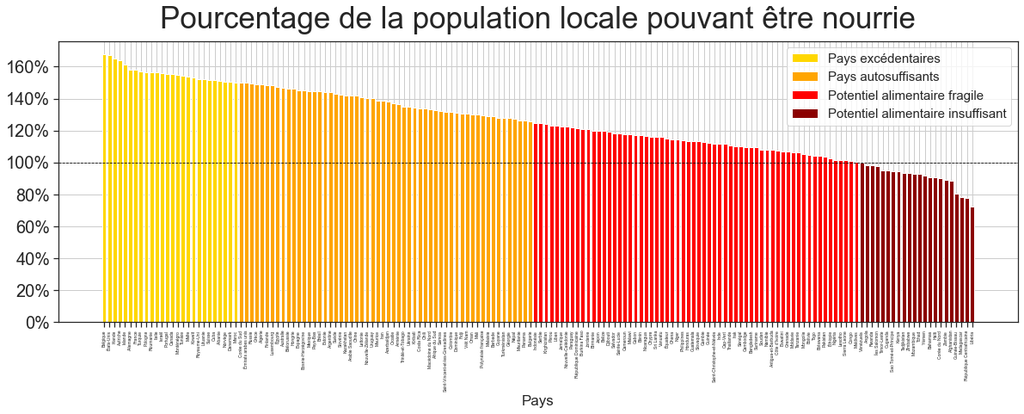

```python
df1=world.sort_values("potentiel", ascending=False).loc[world["potentiel"]>=150]
df2=world.sort_values("potentiel", ascending=False).loc[(world["potentiel"]<150) & (world["potentiel"]>=125)]
df3=world.sort_values("potentiel", ascending=False).loc[(world["potentiel"]<125) & (world["potentiel"]>=100)]
df4=world.sort_values("potentiel", ascending=False).loc[world["potentiel"]<100]

figure = plt.figure(figsize=(20, 6))
axes = figure.add_subplot(111)
axes.axhline(100, linestyle="--", color="black", linewidth=0.8) # Observation des potentiels alimentaires.

palette=["gold", "orange", "red", "darkred"]
leg=["Pays excédentaires", "Pays autosuffisants", "Potentiel alimentaire fragile", "Potentiel alimentaire insuffisant"]

for k, data in enumerate([df1, df2, df3, df4]):
    axes.bar(data.index, data["potentiel"],
             color=palette[k], label=leg[k])

axes.set_title("Pourcentage de la population locale pouvant être nourrie", fontsize=35, pad=15)
plt.xlabel("Pays", fontsize=17)
plt.xticks(fontsize=5, rotation=90)
axes.set_yticklabels(["{}%".format(int(x)) for x in axes.get_yticks()], fontsize=20)
axes.grid(True)
axes.legend(fontsize=15)
plt.show()
```

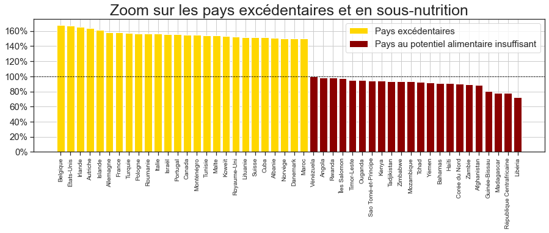

```python
figure = plt.figure(figsize=(15, 4))
axes = figure.add_subplot(111)
axes.axhline(100, linestyle="--", color="black", linewidth=0.8) # États excédentaires et en sous-nutrition.

axes.bar(df1.index, df1["potentiel"], color="gold", label="Pays excédentaires")
axes.bar(df4.index, df4["potentiel"], color="darkred", label="Pays au potentiel alimentaire insuffisant")

axes.set_title("Zoom sur les pays excédentaires et en sous-nutrition", fontsize=25)
plt.xticks(fontsize=10, rotation=90)
axes.set_yticklabels(["{}%".format(int(x)) for x in axes.get_yticks()], fontsize=15)
plt.grid(True)
plt.legend(fontsize=15)
plt.show()
```

Le complexe Nord/Sud apparaît encore une fois clairement sur ce diagramme: alors que plusieurs états d'Europe et d'Amérique du Nord sont en mesure de nourrir plus de 150% de leur population, on distingue notamment des d'Afrique Subsaharienne et d'Asie centrale ne pouvant subvenir aux besoins alimentaires de chacun de leurs habitants. **Cela fait clairement apparaître la cause de la faim dans le monde qui est bel et bien une distribution alimentaire mal répartie.** Enfin, visualisons ce déséquilibre alimentaire mondial sur une nouvelle carte, le complexe Nord/Sud y sera alors encore une fois bien visible.

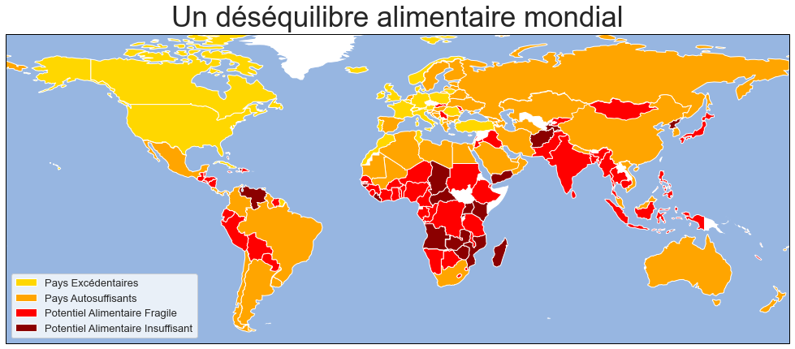

```python
for i in range(1, 5) :
    vars()["Z"+str(i)]=mapzone(vars()["df"+str(i)])

dim(22, 7)
ax = plt.axes(projection=ccrs.PlateCarree())
ax = carte(ax)

cartography([Z1, Z2, Z3, Z4], palette, ax)

plt.legend(legendes(palette),
           ["Pays Excédentaires",
            "Pays Autosuffisants",
            "Potentiel Alimentaire Fragile",
            "Potentiel Alimentaire Insuffisant"],
           loc="lower left", fontsize=13)

plt.title("Un déséquilibre alimentaire mondial", fontsize=35, pad=10)
plt.show()
```

# IV. Finalisation du DataFrame principal

## *IV.1. Disponibilité alimentaire synthétisée*

Nous souhaitons cibler les différents besoins en calories et en protéines des pays en difficulté. Cependant, les deux types de disponibilités alimentaires semblent relativement corrélées comme le confirme le graphique suivant.

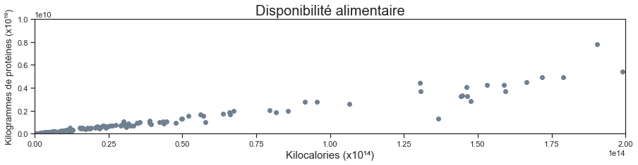

```python
dim(15,3)
plt.plot(world["domestic_supply_kcal"], world["domestic_supply_kgproteine"], "o", color="slategrey")

plt.title("Disponibilité alimentaire", fontsize=20)
plt.xlabel("Kilocalories (x10¹⁴)", fontsize=15)
plt.ylabel("Kilogrammes de protéines (x10¹⁰)", fontsize=13)
plt.xlim(0, 2*10**14)
plt.ylim(0, 10**10)
plt.show()
```

C'est pourquoi, pour l'étude à venir, nous ne considérerons qu'une seule variable représentant ces deux dernières, de façon relativement "impartiale" (ne favorisant aucune des deux unités d'énergie en particulier). Nous ajoutons donc à **world** la variable suivante:

- *domestic_supply* : Qui nous renvoie tout simplement la disponibilité alimentaire en milliers de tonnes de nourriture.

```python
dss=pd.read_csv("data/projet_R/W/alim.csv").drop(columns="exportation").set_index("country")
world=world.join(dss)
world[["population", "undernourished", "domestic_supply"]].head(5)
```

| country | population | undernourished | domestic_supply |
| --- | --- | --- | --- |
| Afghanistan | 36296110.0 | 10600000.0 | 15139.0 |
| Afrique du Sud | 57009760.0 | 3500000.0 | 66840.0 |
| Albanie | 2884170.0 | 200000.0 | 4879.0 |
| Algérie | 41389190.0 | 1600000.0 | 45365.0 |
| Allemagne | 82658410.0 | 0.0 | 174960.0 |

Une analyse des corrélations justifiera cette simplification.

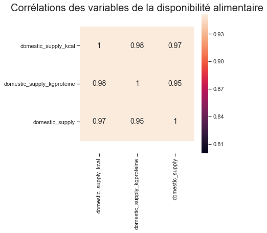

```python
df=world[["domestic_supply_kcal", "domestic_supply_kgproteine", "domestic_supply"]]

dim(5, 5)

sns.heatmap(df.corr(), annot=True, vmax=.8,
            square=True, cbar="plasma")

plt.title("Corrélations des variables de la disponibilité alimentaire", fontsize=20)
plt.axis("equal")
plt.show()
```

Les variables *domestic_supply_kcal* et *domestic_supply_kgproteine* seront donc tout simplement remplacées par *domestic_supply* dans les analyses à venir.

## *IV.2. PIB par habitant*

La sous-nutrition dans le monde relève bien sûr d'un problème d'ordre financier, mais nous verrons que ce n'est pas le seul facteur relatif à ce fléau. Bien que ce projet ait pour ambition de contourner au mieux cet aspect, nous pouvons néanmoins manifester les inégalités économiques dans le monde. C'est pourquoi nous ajoutons au DataFrame **world** la nouvelle variable:

- *pib_hbt* : Qui représente pour chaque pays le PIB par habitant basé sur le dollar américain.

```python
pib = pd.read_csv("data/projet_R/W/gdp.csv").set_index("country")
world = world.join(pib)
world[["population", "undernourished", "pib_hbt"]].head(5)
```

| country | population | undernourished | pib_hbt |
| --- | --- | --- | --- |
| Afghanistan | 36296110.0 | 10600000.0 | 592.777081 |
| Afrique du Sud | 57009760.0 | 3500000.0 | 6121.876237 |
| Albanie | 2884170.0 | 200000.0 | 4516.054387 |
| Algérie | 41389190.0 | 1600000.0 | 4044.290077 |
| Allemagne | 82658410.0 | 0.0 | 44348.834206 |

Nous allons maintenant étudier la répartition des moyens financiers par personne dans le monde au niveau de chaque pays, avec un nuage de points représentant le PIB par habitant en fonction de la population, puis avec une courbe de Lorenz sur la répartition du PIB par habitant dans chaque pays.

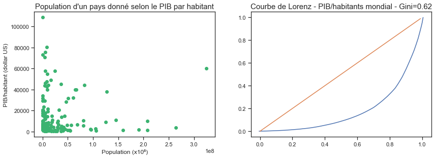

```python
dim(14, 10)


plt.subplot(2, 2, 1)

sci=world.drop(index=["Chine", "Inde"])

plt.plot(sci["population"], sci["pib_hbt"],
         "o", color="mediumseagreen")

plt.xlabel("Population (x10⁸)")
plt.ylabel("PIB/habitant (dollar US)")
plt.title("Population d'un pays donné selon le PIB par habitant", fontsize=15)


plt.subplot(2, 2, 2)

taux = world.sort_values("pib_hbt")["pib_hbt"].values

n = len(taux)
lorenz = np.append([0], np.cumsum(taux)/sum(taux))
gini=2*(0.5-lorenz.sum()/n)

X = arange(0,1,0.01)
plt.plot(np.linspace(0-1/n, 1+1/n, n+1), lorenz)
plot(X, X)

plt.title("Courbe de Lorenz - PIB/habitants mondial - Gini=%s" %(round(gini, 2)), fontsize=15)


plt.show()
```

Ce n'est une découverte pour personne que de dire que l'économie est mal répartie au niveau mondiale. La courbe de Lorenz présente un indice de Gini de 0.62 ce qui marque le fossé entre les pays excédentaires et les pays en sous-nutrition. Sur le graphique de gauche, on comprend que le PIB par habitant peut s'avérer faible pour des pays extrêmement peuplés. Si l'économie était répartie correctement, nous observerions une tendance linéaire croissante sur ce graphique, ce qui n'est pas le cas.

## *IV.3. Récapitulatif du DataFrame WORLD*

**En fin de compte de cette première partie introductive, notre DataFrame principal** **world** **comprend les variables suivantes:**

- **1°)** *population* **:** Le nombre d'habitants par pays.
- **2°)** *undernourished* **:** Le nombre d'habitants en sous-nutrition au sein du pays donné.
- **3°)** *und_percentage* **:** Le pourcentage de la population en sous-nutrition au sein du pays donné.
- **4°)** *domestic_supply_kcal* **:** La disponibilité intérieure annuelle totale en terme de kilocalories.
- **5°)** *domestic_supply_kgproteine* **:** La disponibilité intérieure annuelle totale en terme de kilogrammes de protéines.
- **6°)** *food_supply_kcal* **:** La disponibilité intérieure annuelle totale en nourriture en terme de kilocalories.
- **7°)** *food_supply_kgproteine* **:** La disponibilité intérieure annuelle totale en nourriture en terme de kilogrammes de protéines.
- **8°)** *potentiel_calorie* **:** Qui nous renvoie le pourcentage de la population que le pays en question est en mesure de nourrir en terme de calories.
- **9°)** *potentiel_proteine* **:** Qui nous renvoie le pourcentage de la population que le pays en question est en mesure de nourrir en terme de protéines.
- **10°)** *potentiel* **:** Qui nous renvoie le pourcentage de la population que le pays en question est en mesure de nourrir.
- **11°)** *domestic_supply* **:** La disponibilité alimentaire totale en milliers de tonnes de nourriture.
- **12°)** *pib_hbt* **:** Qui représente pour chaque pays le PIB par habitants basé sur le dollar américain.

```python
world
```

| country | population | undernourished | und_percentage | domestic_supply_kcal | domestic_supply_kgproteine | food_supply_kcal | food_supply_kgproteine | potentiel_calorie | potentiel_proteine | potentiel | domestic_supply | pib_hbt |
| --- | --- | --- | --- | --- | --- | --- | --- | --- | --- | --- | --- | --- |
| Afghanistan | 36296110.0 | 10600000.0 | 29.20 | 3.180962e+13 | 8.481271e+08 | 2.645642e+13 | 7.165887e+08 | 88.755556 | 98.345455 | 88.755556 | 15139.0 | 592.777081 |
| Afrique du Sud | 57009760.0 | 3500000.0 | 6.14 | 9.544646e+13 | 2.774365e+09 | 6.215518e+13 | 1.734602e+09 | 132.755556 | 151.563636 | 132.755556 | 66840.0 | 6121.876237 |
| Albanie | 2884170.0 | 200000.0 | 6.93 | 5.849801e+12 | 1.810956e+08 | 3.579255e+12 | 1.258003e+08 | 151.111111 | 217.272727 | 151.111111 | 4879.0 | 4516.054387 |
| Algérie | 41389190.0 | 1600000.0 | 3.87 | 7.946168e+13 | 2.048977e+09 | 5.053310e+13 | 1.402690e+09 | 148.666667 | 168.818182 | 148.666667 | 45365.0 | 4044.290077 |
| Allemagne | 82658410.0 | 0.0 | 0.00 | 3.676455e+14 | 7.135272e+09 | 1.073762e+14 | 3.139825e+09 | 158.177778 | 189.218182 | 158.177778 | 174960.0 | 44348.834206 |
| ... | ... | ... | ... | ... | ... | ... | ... | ... | ... | ... | ... | ... |
| Émirats arabes unis | 9487200.0 | 200000.0 | 2.11 | 3.095352e+13 | 5.557124e+08 | 1.166973e+13 | 3.714229e+08 | 149.777778 | 195.018182 | 149.777778 | 11795.0 | 39811.647291 |
| Équateur | 16785360.0 | 1300000.0 | 7.74 | 2.162130e+13 | 5.082735e+08 | 1.583741e+13 | 4.029502e+08 | 114.888889 | 119.581818 | 114.888889 | 23810.0 | 6213.501647 |
| États-Unis | 325084760.0 | 0.0 | 0.00 | 1.648094e+15 | 3.316777e+10 | 4.463836e+14 | 1.348050e+10 | 167.200000 | 206.563636 | 167.200000 | 849821.0 | 60044.106651 |
| Éthiopie | 106399920.0 | 21600000.0 | 20.30 | 1.305851e+14 | 3.708195e+09 | 8.947808e+13 | 2.549193e+09 | 102.400000 | 119.345455 | 102.400000 | 55860.0 | 721.662050 |
| Îles Salomon | 636040.0 | 57000.0 | 8.96 | 9.642980e+11 | 1.636241e+07 | 5.594926e+11 | 1.245277e+07 | 107.111111 | 97.527273 | 97.527273 | 989.0 | 1885.005100 |

166 rows × 12 columns

*Retour au sommaire*

# Mission 2: Analyse des variables et explication de la sous-nutrition

# I. Analyse des corrélations

## *I.1. Matrice des corrélations*

L'objectif de cette deuxième mission est d'expliquer la sous-nutrition selon les variables étudiées. Nous rappelons que l'on distingue deux types de problème dans ce sujet:

- Les pays recensants le plus d'êtres humains en sous-nutrition donnés par la variable *undernourished*.
- Les pays présentant les plus forts pourcentages de la population locale en sous-nutrition donnés par la variable *und_percentage*.

Analysons les corrélations entre chacune des variables étudiées pour le clustering, deux à deux, avec un tableau de contingence coloré, et observons les corrélations liées à la population ainsi qu'aux deux variables de la sous-nutrition.

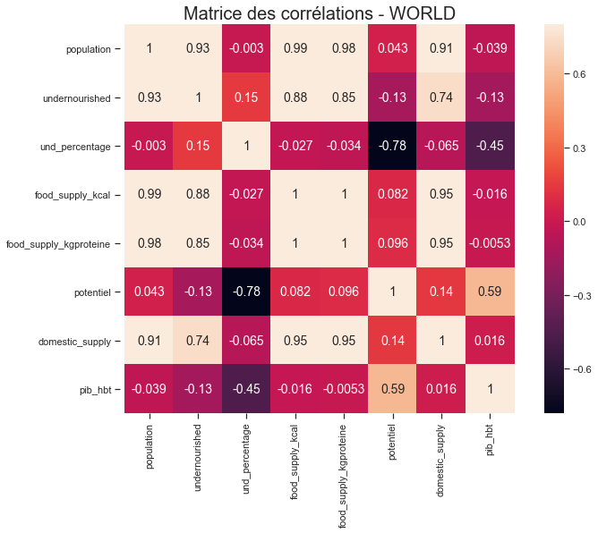

```python
df=world.drop(columns=["domestic_supply_kcal", "domestic_supply_kgproteine", "potentiel_calorie", "potentiel_proteine"])

dim(10, 8)

sns.heatmap(df.corr(), annot=True, vmax=.8,
            square=True, cbar="plasma")

plt.axis("equal")
plt.title("Matrice des corrélations - WORLD", fontsize=20)
plt.show()
```

**Observations**

**Population:** On remarque tout d'abord une très faible corrélation entre le nombre d'habitants d'un pays donné (population) et son pourcentage de sous-nutrition. La Chine et l'Inde sont deux exceptions de par leur population excessivement grande par rapport au reste du monde, mais l'on en déduit d'un point de vue général que ce ne sont pas forcément les pays les plus peuplés qui souffrent le plus de la sous-nutrition à l'échelle locale. En revanche, la population est naturellement fortement corrélée à chaque variable donnant une estimation de la disponibilité alimentaire du pays. Plus un pays est peuplé, plus il est productif au niveau de l'agriculture et de la production alimentaire.

## *I.2. Cercle des corrélations*

Réalisons maintenant une ACP sur nos données afin d'analyser l'inertie des variables regroupées sur un cercle des corrélations. Nous pourrons alors dégager certaines estimations sensiblement liées entre deux variables pour un pays donné. Nous ne nous intéresserons qu'au premier plan factoriel.

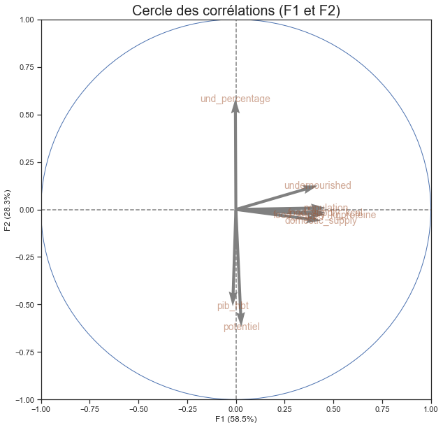

```python
X=df.values
std_scaler = preprocessing.StandardScaler().fit(X)
X_scaled = std_scaler.transform(X)

data_pca = pd.DataFrame(X_scaled, columns=df.columns, index=df.index)
data_pca = data_pca.fillna(data_pca.mean())
names, features = data_pca.index, data_pca.columns

n_comp=8
pca = decomposition.PCA(n_components=n_comp)
pca.fit(X_scaled)

# Présentons les deux nouvelles variables créées dans le tableau appelé "composantes":
composantes=pd.DataFrame(pca.fit_transform(X_scaled), index=world.index)
composantes.columns=["F1", "F2", "F3", "F4", "F5", "F6", "F7", "F8"]

pcs = pca.components_
display_circles(pcs, n_comp, pca, [(0,1)], labels = np.array(features))
```

On retrouve bien la non-corrélation entre les variables **undernourished** et **und_percentage**, dont les vecteurs sont quasiment orthogonnaux. Il est intéressant de voir que l'ensemble des variables autour du nombre d'êtres humains en sous-nutrition forment plus de 50% de l'inertie totale, tandis que près de 30% s'explique par des variables corrélées au pourcentage de sous-nutrition. C'est en se basant sur le cercle des corrélations ci-dessus que nous choisirons les variables explicatives pour une ANOVA sur chacune de ces deux variables, qui nous permettra maintenant de les expliquer plus spécifiquement.

# II. Analyse de la variance de la sous-nutrition

## *II.1. Préparatifs des analyses*

On s'intéresse aux variables *undernourished* et **_und*percentage*** du DataFrame **world** et nous présentons en premier lieu les mesures de tendance centrale de ces variables dans une boîte à moustaches.

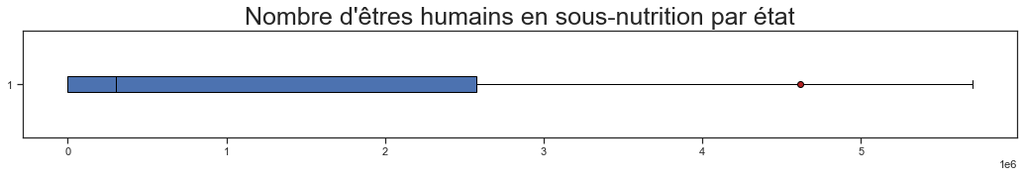

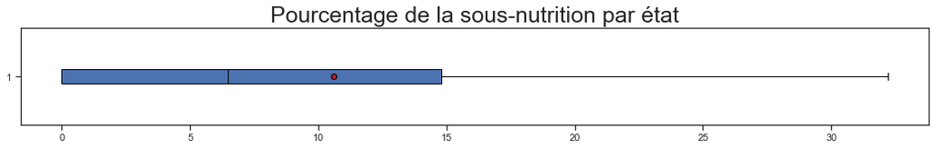

```python
# On définit ici les paramètres des boxplots pour toute la suite du projet :
medianprops = {"color":"black"}
meanprops = {"marker":"o", "markeredgecolor":"black", "markerfacecolor":"firebrick"}

dim(18, 2)
plt.boxplot(world["undernourished"], showfliers=False, medianprops=medianprops,
            vert=False, patch_artist=True,showmeans=True, meanprops=meanprops)
plt.title("Nombre d'êtres humains en sous-nutrition par état", fontsize=25)
plt.show()

dim(18, 2)
plt.boxplot(world["und_percentage"], showfliers=False, medianprops=medianprops,
            vert=False, patch_artist=True, showmeans=True, meanprops=meanprops)

plt.title("Pourcentage de la sous-nutrition par état", fontsize=25)
plt.show()
```

Pour l'étude du nombre de personnes en sous-nutrition: Si nous prenions en compte l'Inde et la Chine, cela pourrait fausser nos données. En effet, nous pouvons observer sur l'ensemble des graphiques jusqu'à maintenant que ces deux pays se distinguaient de par leur population. C'est pourquoi nous considérerons à part ces deux états, afin d'estimer d'autres variables que la taille de la population pour expliquer la sous-nutrition, en les excluant de l'analyse de la variance.

Pour l'étude des pourcentages de la sous-nutrition, nous réduirons les données en pourcentage afin de comparer des grandeurs similaires.

```python
nt = 0.05 # Fixation du niveau de test statistique pour l'ensemble du projet.

world_num = world.drop(index=["Chine", "Inde"])
world_num["pib"]=world_num["population"]*world_num["pib_hbt"]
world_num["potentiel"]*=world_num["population"]/100

world_per = world.copy()
world_per["population"]/=(0.01*POPULATION)
DS=world["domestic_supply"].sum()
world_per["domestic_supply"]/=(0.01*DS)
```

En vue des analyses répétées que nous exécuterons sur les **résidus des modélisations** à venir, nous créons ici les fonctions décrites ci-dessous qui prendront toutes en entrée une modélisation donnée pour renvoyer un certain résultat sur ses résidus. À noter que les différents tests d'adéquation à une loi gausienne que nous exécuterons testeront donc l'adéquation d'une certaine variable X à la loi normale de paramètres (mean(X), std(X)).

- 1°) **"residus_henry"**: qui nous superposera les résidus d'une modélisation donnée avec la droite de Henry.
- 2°) **"nuage_residuel"**: qui nous renverra le nuage de la variance résiduelle.
- 3°) **"analyse des résidus"**: qui nous renverras la droite de Henry ET le nuage de la variance résiduelle.
- 4°) **"test_shapiro"**: qui nous renverra les résultats d'un test de Shapiro sur les résidus (peu probable qu'on s'en serve vu la taille des échantillons).
- 5°) **"test_residus_KS"**: qui nous renverra les résultats d'un test de Kolmogorov-Smirnoff sur les résidus.
- 6°) **"test_residus_BP"**: qui nous renverra les résultats d'un test de Breusch-Pagan sur les résidus en vue de l'analyse de leur homoscédasticité.
- 7°) **"VIF"**: qui renvoie les coefficients de multicolinéarité des variables explicatives d'une régression linéaire multiple.
- 8°) **"decomposition_des_variables"**: qui renvoie le pourcentage de contribution de chaque variable explicative d'une régression linéaire multiple.

Pour chaque analyse des résidus d'un modèle de régression, nous observerons son éventuelle adéquation à la loi normale sur la droite de Henry, et son homoscédasticité sur le nuage de variance résiduelle.

```python
# 1°) Droite de Henry :
def residus_henry(MODEL, nom, couleur, ax):
    sm.qqplot(MODEL.resid, ax=ax, line="45", fit=True, color=couleur)
    ax.set_title("Droite de Henry - Résidus de %s" %nom, fontsize=18)
    ax.set_xlabel("Quantiles théoriques" ,fontsize=16), ax.set_ylabel("Quantiles observés", fontsize=16)

# 2°) Nuage de la variance résiduelle :
def nuage_residuel(MODEL, nom, couleur, ax):
    ax=plt.plot(MODEL.fittedvalues, MODEL.resid, ".", color=couleur, alpha=0.3)
    plt.title("Nuage de la variance résiduelle de %s" %nom, fontsize=18)
    plt.xlabel("Population", fontsize=16), plt.ylabel("Résidus", fontsize=16)

# 3°) Les deux en même temps :
def analyse_des_residus(MODEL, nom, couleur):
    fig, (ax1, ax2) = plt.subplots(1, 2, figsize=(15, 5))
    residus_henry(MODEL, nom, couleur, ax1)
    nuage_residuel(MODEL, nom, couleur, ax2)

# 4°) Test de Shapiro :
def test_shapiro(MODEL):
    SH=shapiro(MODEL.resid)
    print("TEST DE SHAPIRO:", " statistic =", SH[0], " pvalue =", SH[1])

# 5°) Test de Kolmogorov-Smirnov :
def test_residus_KS(MODEL):
    MR=MODEL.resid
    KS=ks_2samp(MR,list(np.random.normal(MR.mean(), MR.std(), len(MR))))
    print("TEST DE KOLMOGOROV-SMIRNOV:", " statistic =", KS[0], " pvalue =", KS[1])

# 6°) Test de Breusch-Pagan :
def test_residus_BP(MODEL):
    BP=sm.stats.diagnostic.het_breuschpagan(MODEL.resid, MODEL.model.exog)
    print("TEST DE BREUSCH-PAGAN:", " statistic =", BP[0], " pvalue =", BP[1])

# 7°) Coefficients de multicolinéarité :
def VIF(RLM, variables):
    MEX=RLM.model.exog
    return(pd.DataFrame({"VIF de la variable": [variance_inflation_factor(MEX, i) for i in np.arange(1, MEX.shape[1])]},
                        index=variables))

# 8°) Pourcentage de contribution des variables explicatives :
def decomposition_des_variables(RLM):
    data=sm.stats.anova_lm(RLM, typ=1)
    ssq=data[["sum_sq"]]
    ssq=np.round(100*ssq/ssq.sum(), 2)
    ssq["sum_sq"]=ssq.sum_sq
    ssq.columns=["Pourcentage de l'explication de la variance"]
    return(ssq)
```

## *II.2. Variance de la sous-nutrition*

Réalisons maintenant l'ANOVA sur la variable **undernourished**, le nombre d'êtres humains en sous-nutrition. Nous analyserons également l'adéquation des résidus à la loi normale ainsi que l'homoscédasticité du modèle respectivement sur la droite de Henry et sur le nuage de la variancce résiduelle.

```
                            OLS Regression Results
==============================================================================
Dep. Variable:         undernourished   R-squared:                       0.826
Model:                            OLS   Adj. R-squared:                  0.821
Method:                 Least Squares   F-statistic:                     188.5
Date:                Thu, 15 Apr 2021   Prob (F-statistic):           3.03e-59
Time:                        21:40:37   Log-Likelihood:                -2638.5
No. Observations:                 164   AIC:                             5287.
Df Residuals:                     159   BIC:                             5302.
Df Model:                           4
Covariance Type:            nonrobust
==============================================================================
```

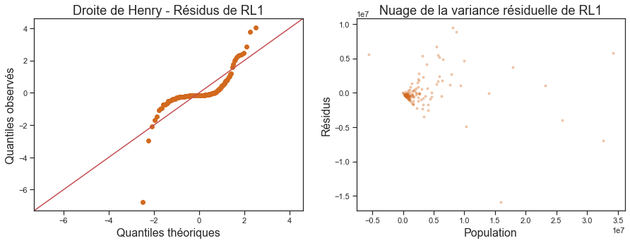

```python
RL1 = ols("undernourished ~ population+pib+potentiel+domestic_supply", data=world_num).fit(alpha=nt)

print(RL1.summary().tables[0])

analyse_des_residus(RL1, "RL1", "chocolate")
```

```python
decomposition_des_variables(RL1)
```

|  | Pourcentage de l'explication de la variance |
| --- | --- |
| population | 35.66 |
| pib | 26.95 |
| potentiel | 19.94 |
| domestic_supply | 0.04 |
| Residual | 17.42 |

C'est donc sans surprise que la taille de la population influe fortement sur le nombre d'êtres humains en sous-nutrition, c'est le facteur explicatif principal de cette variance. Observons ensuite le rôle du PIB par habitant et du potentiel alimentaire, tous deux corrélés entre eux. Ces deux variables n'expliquent qu'à elles seules que moins de 50% de la variance. Nous pouvons en déduire qu'un pays riche et peuple n'est pas à l'abri d'un fort taux d'êtres humains en sous-nutrition, comme nous le verrons notamment plus tard avec l'Inde et la Chine (que nous avons pourtant retiré de cette analyse).

## *II.3. Variance du pourcentage de la sous-nutrition*

Nous allons maintenant nous intéresser au pourcentage de la population locale en sous-nutrition dans chaque pays. Nous pouvons à nouveau considérer l'Inde et la Chine. Comme pour le schéma précédent, nous interpreterons également l'analyse des résidus directement sous le sommaire du modèle.

```
                            OLS Regression Results
==============================================================================
Dep. Variable:         und_percentage   R-squared:                       0.610
Model:                            OLS   Adj. R-squared:                  0.606
Method:                 Least Squares   F-statistic:                     127.7
Date:                Thu, 15 Apr 2021   Prob (F-statistic):           4.27e-34
Time:                        21:40:39   Log-Likelihood:                -581.34
No. Observations:                 166   AIC:                             1169.
Df Residuals:                     163   BIC:                             1178.
Df Model:                           2
Covariance Type:            nonrobust
==============================================================================
```

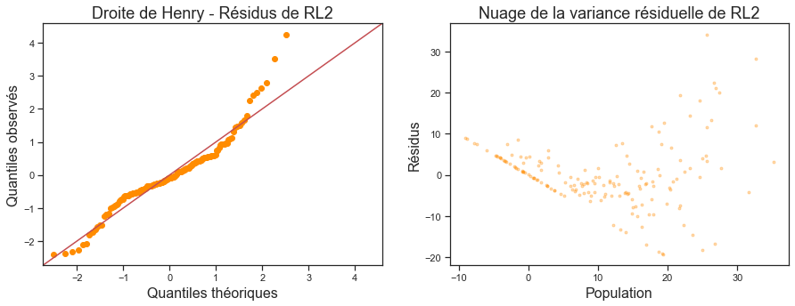

```python
RL2 = ols("und_percentage ~ pib_hbt+potentiel", data=world_per).fit(alpha=nt)

print(RL2.summary().tables[0])

analyse_des_residus(RL2, "RL2", "darkorange")
```

Pour les mêmes raisons que dans le premier modèle, les résidus manifestent un modèle fiable. Nous parvenons à expliquer **61%** de la variance du pourcentage de la sous-nutrition d'après le R². Décomposons donc les variables explicatives de ce modèle.

```python
decomposition_des_variables(RL2)
```

|  | Pourcentage de l'explication de la variance |
| --- | --- |
| pib_hbt | 20.62 |
| potentiel | 40.43 |
| Residual | 38.95 |

C'est donc le potentiel alimentaire qui joue avant tout sur le pourcentage de la sous-nutrition. Cette variable s'accompagne bien sûr de la disponibilité intérieure en nourriture, en calories et en protéines comme nous pouviens l'observer sur la matrice des corrélations. C'est donc avant toute chose cette mauvaise répartition alimentaire mondiale qui creuse ce pourcentage dans beaucoup de pays.

*Retour au sommaire*

# Mission 3: Ciblage des zones dans le besoin alimentaire

# I. Classification hiérarchique des états

## *I.1. Dendrogramme*

- *population* : Le nombre d'habitants.
- *und_percentage* : Le pourcentage de la population en sous-nutrition.
- *potentiel* : Le pourcentage de la population pouvant potentiellement être nourrie avec la disponibilité intérieure locale.
- *pib_hbt* : Le PIB par habitants.
- *food_supply_kcal* : La disponibilité intérieure totale en calories.
- *food_supply_kgproteine* : La disponibilité intérieure totale en protéines.

```python
df=world[["population",
          "undernourished",
          "und_percentage",
          "potentiel",
          "pib_hbt",
          "food_supply_kcal",
          "food_supply_kgproteine"]]

df.head(100).tail(4)
```

| country | population | undernourished | und_percentage | potentiel | pib_hbt | food_supply_kcal | food_supply_kgproteine |
| --- | --- | --- | --- | --- | --- | --- | --- |
| Mongolie | 3113790.0 | 400000.0 | 12.85 | 105.288889 | 3671.935391 | 2.692448e+12 | 9.359352e+07 |
| Monténégro | 627560.0 | 0.0 | 0.00 | 154.577778 | 7738.881296 | 7.966686e+11 | 2.591120e+07 |
| Mozambique | 28649020.0 | 8300000.0 | 28.97 | 93.054545 | 461.414721 | 2.406131e+13 | 5.351837e+08 |
| Birmanie | 53382520.0 | 5700000.0 | 10.68 | 120.044444 | 1245.548423 | 5.262796e+13 | 1.818889e+09 |

Nous allons maintenant donner le tableau centré-réduit de df, que nous appellerons X_scaled, et en tirer un dendrogramme pour estimer un nombre raisonnable de clusters à effectuer.

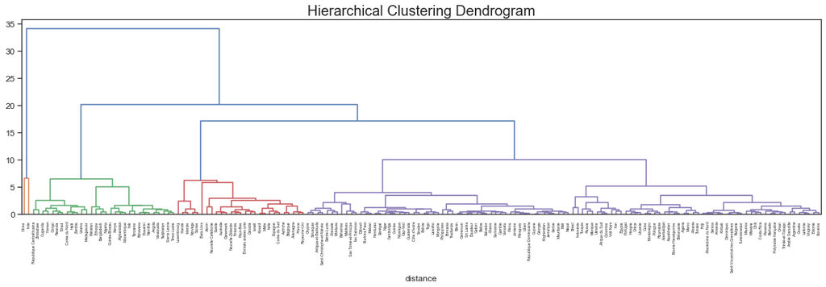

```python
X=df.values
std_scaler = preprocessing.StandardScaler().fit(X)
X_scaled = std_scaler.transform(X)

Z = linkage(X_scaled, "ward")
plot_dendrogram(Z, world.index)
```

## *I.2. Clustering et projection des états sur le 1er plan factoriel*

Nous découpons ici le dendrogramme en 5 clusters afin d"associer chaque pays à un groupe, variable que nous ajoutons à **world** ainsi qu'à **df** .Nous projetons ici chaque pays affecté à son cluster sur le 1er plan factoriel afin de vérifier que les groupes déterminés par notre clustering sont bien distincts.

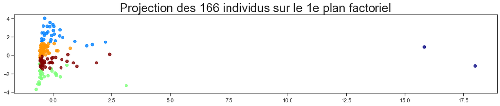

```python
clusters = fcluster(Z, 5, criterion="maxclust")

world["cluster"]=clusters
df["cluster"]=clusters

km = KMeans(n_clusters=5)
km.fit(X_scaled)
pca2 = decomposition.PCA(n_components=4).fit(X_scaled)
X_scaled_projected = pca2.transform(X_scaled)

dim(18,3)

plt.scatter(X_scaled_projected[:, 0], X_scaled_projected[:, 1], c=clusters.astype(np.float), cmap="jet", alpha=.8)

plt.title("Projection des {} individus sur le 1e plan factoriel".format(X_scaled_projected.shape[0]), fontsize=25)
plt.show()
```

Le clustering disperse bien les cinq clusters formés en cinq groupes distincts sur le plan factoriel, ce qui assure la fiabilité du modèle.

## *I.3. Description des clusters*

Bien entendu, nous n'allons pas procéder à notre analyser sur les cinq groupes de pays obtenus sans d'abord les visualiser sur notre carte mondiale et affichons en-dessous la liste des pays étudiés selon le cluster déterminé par notre algorithme.

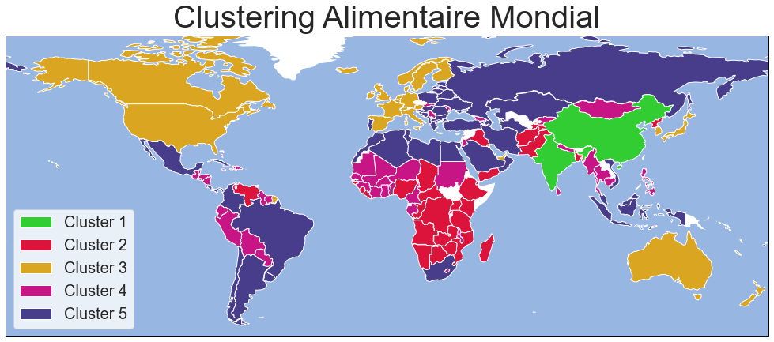

|  | Cluster 1 | Cluster 2 | Cluster 3 | Cluster 4 | Cluster 5 |
| --- | --- | --- | --- | --- | --- |
| 0 | Chine | Afghanistan | Allemagne | Antigua-et-Barbuda | Afrique du Sud |
| 1 | Inde | Angola | Australie | Bahamas | Albanie |
| 2 | - | Bangladesh | Autriche | Belize | Algérie |
| 3 | - | Botswana | Belgique | Bolivie | Arabie Saoudite |
| 4 | - | Congo | Canada | Burkina Faso | Argentine |
| 5 | - | Eswatini | Danemark | Bénin | Arménie |
| 6 | - | Guinée-Bissau | Espagne | Cap-Vert | Azerbaïdjan |
| 7 | - | Haïti | Finlande | Cambodge | Barbade |
| 8 | - | Irak | France | Cameroun | Bosnie-Herzégovine |
| 9 | - | Kenya | Irlande | Chypre | Brésil |
| 10 | - | Libéria | Islande | Côte d'Ivoire | Bulgarie |
| 11 | - | Madagascar | Israël | Djibouti | Biélorussie |
| 12 | - | Mozambique | Italie | Salvador | Chili |
| 13 | - | Namibie | Japon | Gabon | Colombie |
| 14 | - | Nigéria | Koweït | Gambie | Costa Rica |
| 15 | - | Ouganda | Luxembourg | Ghana | Croatie |
| 16 | - | Pakistan | Malte | Grenade | Cuba |
| 17 | - | Rwanda | Norvège | Guatemala | Dominique |
| 18 | - | République Centrafricaine | Nouvelle-Calédonie | Guinée | Estonie |
| 19 | - | Corée du Nord | Nouvelle-Zélande | Guyane | Fidji |
| 20 | - | Tanzanie | Pays-Bas | Géorgie | Russie |
| 21 | - | Sierra Leone | Royaume-Uni | Honduras | Grèce |
| 22 | - | Tadjikistan | Corée du Sud | Jamaïque | Hongrie |
| 23 | - | Tchad | Suisse | Jordanie | Indonésie |
| 24 | - | Timor-Leste | Suède | Kirghizistan | Iran |
| 25 | - | Vénézuela | Émirats arabes unis | Lesotho | Kazakhstan |
| 26 | - | Yémen | États-Unis | Liban | Kiribati |
| 27 | - | Zambie | - | Malawi | Lettonie |
| 28 | - | Zimbabwe | - | Maldives | Lituanie |
| 29 | - | Éthiopie | - | Mali | Macédoine du Nord |
| 30 | - | - | - | Mauritanie | Malaisie |
| 31 | - | - | - | Mongolie | Maroc |
| 32 | - | - | - | Birmanie | Maurice |
| 33 | - | - | - | Nicaragua | Mexique |
| 34 | - | - | - | Niger | Monténégro |
| 35 | - | - | - | Népal | Oman |
| 36 | - | - | - | Paraguay | Panama |
| 37 | - | - | - | Philippines | Pologne |
| 38 | - | - | - | Pérou | Polynésie française |
| 39 | - | - | - | Moldavie | Portugal |
| 40 | - | - | - | République Dominicaine | Roumanie |
| 41 | - | - | - | Saint-Christophe-et-Niévès | Saint-Vincent-et-les-Grenadines |
| 42 | - | - | - | Sainte-Lucie | Samoa |
| 43 | - | - | - | Sao Tomé-et-Principe | Slovénie |
| 44 | - | - | - | Serbie | Trinité-et-Tobago |
| 45 | - | - | - | Slovaquie | Tunisie |
| 46 | - | - | - | Soudan | Turkménistan |
| 47 | - | - | - | Sri Lanka | Turquie |
| 48 | - | - | - | Suriname | Ukraine |
| 49 | - | - | - | Sénégal | Uruguay |
| 50 | - | - | - | Thaïlande | Viêt Nam |
| 51 | - | - | - | Togo | Égypte |
| 52 | - | - | - | Vanuatu | - |
| 53 | - | - | - | Équateur | - |
| 54 | - | - | - | Îles Salomon | - |

```python
def world_cluster(n): return(world.loc[world["cluster"]==n]) # Nous renvoie la liste des pays affectés au cluster n.


for i in range(1, 6):

    vars()["w"+str(i)] = world_cluster(i) # wi pour i allant de 1 à 5 sera la restriction de world au cluster i.

    vars()["C"+str(i)] = mapzone(vars()["w"+str(i)]) # Liste des codes ISO des pays du cluster i.



palette=["limegreen", "crimson", "goldenrod", "mediumvioletred", "darkslateblue"] # On attribuera ces couleurs aux 5 clusters.


dim(22, 7)

ax = plt.axes(projection=ccrs.PlateCarree())
ax = carte(ax)

cartography([C1, C2, C3, C4, C5], palette, ax)

plt.legend(legendes(palette), ["Cluster %s" %i for i in range(1, 6)], loc="lower left", fontsize=20)
plt.title("Clustering Alimentaire Mondial", fontsize=40, pad=10)
plt.show()



cl=pd.DataFrame({"Cluster %s" %i: [0]*55 for i in range(1, 6)})

for i in range(1, 6):
    CLI="Cluster %i" %i
    countries=list(df.loc[df["cluster"]==i].index.values)
    cl[CLI]=countries+["-"]*(55-len(countries))
cl
```

Il est maintenant intéressant d'étudier ce que représentent ces cinq clusters si l'on étudie les variables deux à deux, et relever ce qui est significatif pour chacun de ces groupes.

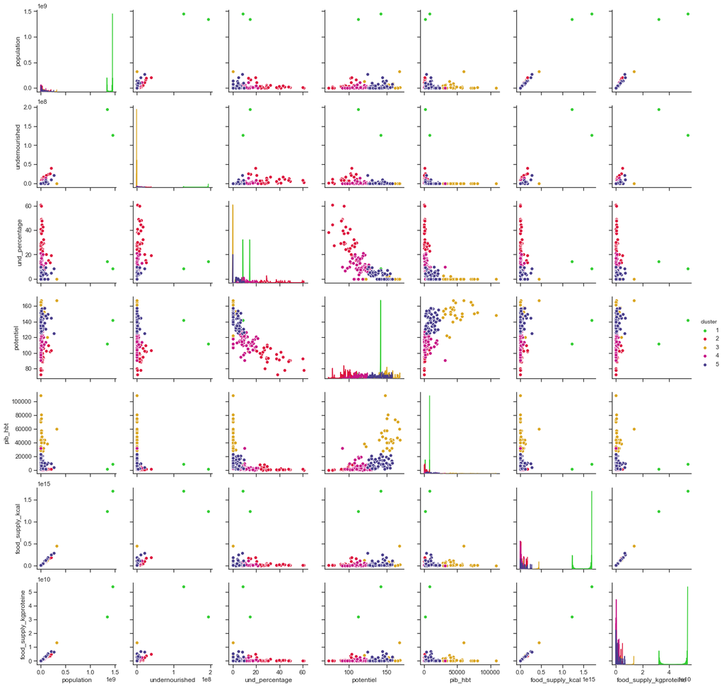

```python
sns.pairplot(df, vars = df.drop(columns="cluster").columns,
             palette=palette, hue="cluster", diag_kws={"bw": 0.1})
plt.show()
```

Nous nous aiderons de ces graphiques pour définir au mieux les clusters. Remarquons au passage que le clustering se démarque bien sur chaque graphe. On affiche maintenant les valeurs moyennes des variables de chacun de ces clusters.

```python
groupes=pd.DataFrame(df.groupby("cluster").mean())

groupes["Nombre de pays"]=[len(df.loc[df["cluster"]==i]) for i in range(1, 6)]
groupes
```

| cluster | population | undernourished | und_percentage | potentiel | pib_hbt | food_supply_kcal | food_supply_kgproteine | Nombre de pays |
| --- | --- | --- | --- | --- | --- | --- | --- | --- |
| 1 | 1.395651e+09 | 1.603892e+08 | 11.610000 | 126.840281 | 5295.362994 | 1.460864e+15 | 4.291233e+10 | 2 |
| 2 | 3.867057e+07 | 9.522432e+06 | 33.377667 | 95.583098 | 1984.492492 | 3.279732e+13 | 8.340134e+08 | 30 |
| 3 | 3.672576e+07 | 1.111111e+04 | 0.169630 | 151.068313 | 49747.582689 | 4.635195e+13 | 1.415967e+09 | 27 |
| 4 | 1.307981e+07 | 1.568421e+06 | 10.279636 | 114.404995 | 5065.916774 | 1.285785e+13 | 3.322567e+08 | 55 |
| 5 | 3.186200e+07 | 1.400571e+06 | 3.177308 | 140.209324 | 10231.272413 | 3.696138e+13 | 1.036878e+09 | 52 |

**Cluster 1:** Il ne contient que l'Inde et la Chine. Outliers dans nos données de par leur population excessivement grande par rapport aux autres. Ce sont deux pays puissants économiquement mais dont la démographie tend à la sous-nutrition. Comme présenté en introduction, il s'agit des deux pays recenssant la plus forte sous-nutrition en terme de nombre d'habitants, mais pas en terme de pourcentage de la population locale.

**Cluster 2:** Il regroupe les états comprenant les pourcentages de population en sous-nutrition les plus élevés. On y trouve par exemple la Zimbabwe et la République Centrafricaine où ces pourcentages s'élèvent respectivement à 59,71% et à 60,92%. On y observe donc:

- 30 pays, en relevant massivement des états d'Afrique Subsaharienne et d'Asie Centrale.
- Un total d'êtres humains en sous-nutrition très important.
- Les pourcentages de la population locale en sous-nutrition dans chaque pays sont très élevés.
- Potentiel nutritif insuffisant.
- PIB par habitant faible.
- Disponibilité alimentaire intérieure faible.

**Cluster 3:** Il regroupe des pays développés, notamment d'Europe de l'ouest et d'Amérique du nord. Ce sont les pays où le PIB par habitant est le plus fort, ainsi que les moins touchés par la sous-nutrition. On y observe donc:

- 27 pays développés, notamment des pays de l'Union Européenne, d'Europe centrale ainsi que les États-Unis.
- Un taux d'êtres humains en sous-nutrition très faible.
- Un PIB par habitant très élevé et une disponibilité alimentaire excédentaire.

- 55 pays, dont des états d'Afrique Centrale, d'Asie Occidentale et d'Amérique Latine.
- Pays à faible population, disponibilité alimentaire basse à l'échelle mondiale.
- Un taux d'êtres humains en sous-nutrition sensiblement élevé et des pourcentages locaux plutôt faibles.
- PIB par habitant relativement faible.
- Potentiel nutritif fragile.

**Cluster 5:** Ce dernier cluster, semblable au cluster 3, se distingue de ce dernier par un taux de sous-nutrition bien présent. On peut donc présumer que la famine relate de problèmes d'ordre politique dans ces pays, plutôt que de problèmes de disponibilité alimentaire. On y observe donc:

- 52 pays, Afrique du Nord, Europe de l'Est et Amérique du Sud.
- Des pays relativement développés, au potentiel alimentaire autosuffisant mais présentant tout de même la sous-nutrition.

```python
world.to_csv("data/projet_R/world.csv") # On enregistre notre DataFrame world mis à jour avec les clusters.
```

# II. Analyses graphiques interclusters

## *II.1. Fonctions préliminaires*

Nous nous servirons tout au long de cette partie des fonctions:

- 1°) **data_cluster**: qui prend en argument un DataFrame et un entier n compris entre 1 et 5 et qui renvoie la restriction de ce DataFrame au cluster n.
- 2°) **data_pie**: qui prend en argument un DataFrame et une de ses variables X pour nous renvoyer un camembert donnant la répartition en pourcentage de la somme totale de la variable X prise en argument pour chaque cluster dans ce DataFrame.
- 3°) **data_bar**: qui prend en argument un DataFrame et une de ces variables X pour nous renvoyer un diagramme en tuyau d'orgues coloré selon les clusters, avec les pays en abscisses et la variable X en ordonnées.
- 4°) **data_per**: qui représentera mieux le diagramme si X est une variable en pourcentage.
- 5°) **world_cluster, world_pie et world_bar/per**: respectivement ces trois dernières fonctions appliquées direcement au DataFrame **world**.

```python
# 1°) data_cluster:
def data_cluster(data, n): return(data.loc[data["cluster"]==n])


# 2°) data_pie:
def data_pie(data, X):
    pd.DataFrame(data[[X, "cluster"]].groupby("cluster").sum())[X].plot(kind="pie", colors=palette, labels=["","","","",""],
                                           autopct=lambda x: str(round(x, 2))+"%", shadow=True, textprops={"color":"w"})

    plt.legend(["Cluster %s" %i for i in range(1, 6)], loc="lower right", fontsize=10)
    plt.ylabel("")


# 3°) data_bar:
def data_bar(data, X):
    for i in range(1, 6): vars()["w"+str(i)] = data_cluster(data, i)

    for i, wx in enumerate([w1, w2, w3, w4, w5]):
        if len(wx)!=0: plt.bar(wx.index, wx[X], color=palette[i], label="Cluster {}".format(i+1))

    if max(world[X])<500 and min(world[X])!=0:
        plt.axhline(100, linestyle="--", color="black", linewidth=0.8)

    plt.xticks(fontsize=5, rotation=90)
    plt.legend(fontsize=15, loc="upper right")


# 4°) data_per:
def data_per(data, X, axx):
    for i in range(1, 6): vars()["w"+str(i)] = data_cluster(data, i)

    for i, wx in enumerate([w1, w2, w3, w4, w5]):
        if len(wx)!=0: axx.bar(wx.index, wx[X], color=palette[i], label="Cluster {}".format(i+1))

    if max(world[X])<500 and min(world[X])!=0:
        axx.axhline(100, linestyle="--", color="black", linewidth=0.8)

    axx.set_yticklabels(["{}%".format(int(x)) for x in axes.get_yticks()], fontsize=15)
    plt.xticks(fontsize=5, rotation=90); plt.legend(fontsize=15, loc="upper right")


# 5°) Fonctions associées directement à WORLD:
def world_cluster(n): return(data_cluster(world, n)) ;
def world_pie(X): data_pie(world, X) ;
def world_bar(X): data_bar(world, X) ;
def world_per(X, axx): data_per(world, X, axx)
```

## *II.2. Représentations des clusters à l'échelle mondiale*

Commençons donc par observer la répartition de la population mondiale et la répartition du nombre d'êtres humains en sous-nutrition parmi les clusters.

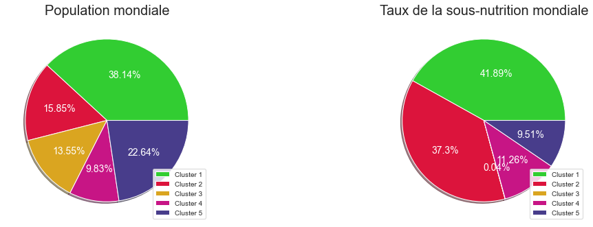

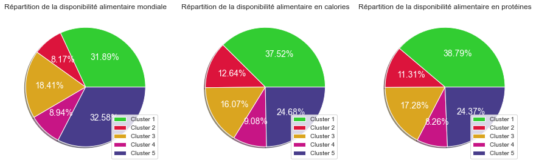

```python
dim(18, 12)

plt.subplot(2, 2, 1)
world_pie("population")
plt.title("Population mondiale", fontsize=20)

plt.subplot(2, 2, 2)
world_pie("undernourished")
plt.title("Taux de la sous-nutrition mondiale", fontsize=20)

plt.show()


dim(15, 5)

k=1
for X in ["domestic_supply", "food_supply_kcal", "food_supply_kgproteine"]:

    plt.subplot(1, 3, k)
    world_pie(X)

    if k==1: plt.title("Répartition de la disponibilité alimentaire mondiale")
    elif k==2: plt.title("Répartition de la disponibilité alimentaire en calories")
    else: plt.title("Répartition de la disponibilité alimentaire en protéines")

    k+=1

plt.show()
```

Rappelons que le cluster 1 représente l'Inde et la Chine. Ces deux pays représentent en effet près de 38% de la population mondiale, ainsi que 42% de la sous-nutrition globale. Ce sont des zones cibles prioritaires dans le cadre de la lutte contre la faim dans le monde. Nous pourrons également observer les pays du cluster 2, représentant 15,85% de la population totale ainsi que 37,3% de la sous-nutrition. Ces taux s'expliquent par des pays à population plus faibles, mais recensant donc un pourcentage de la population locale en sous-nutrition plus important. Enfin, remarquons que le cluster 4 est relativement concerné par les mêmes critères que le cluster 2, mais avec des proportions plus faibles. Observons maintenant les différentes répartitions de la disponibilité alimentaie mondiale parmi ces clusters.

Remarquons que seuls les Clusters 3 et 5 possèdent une disponibilité alimentaire plus importante que leur représentation démographique à l'échelle mondiale. En effet, c'est dans ces clusters que nous trouverons les états autosuffisants voire excédentaires, mais nous recensons tout de même la sous-nutrition dans le cluster 5. Rappelant que nous avons observé lors de la mission 1 que nous pouvions aisément nourrir plus de 120% de la population, établir que 1% du monde possède 1% de la disponibilité alimentaire mondiale est alors déjà un critère d'excédentaire. L'Inde et la Chine présentent des taux similaires pour ce qui est de leur taux de population mondiale respectifs et de leurs taux de disponibilité alimentaires mondiale.

Nous pouvons donc émettre les hypothèses suivantes:

- Les pays des clusters 1 et 5 doivent leurs taux de sous-nutrition à leur politique intérieure. Ils disposent de ressources suffisantes pour nourrir leur population mais ne les distribuent pas à bon escient.
- Les pays du cluster 3 sont généralement excédentaires. Ils sont autosuffisants et n'auront pour l'instant pas recours à un remaniement politique intérieur ou à une quelconque aide humanitaire.
- Les pays des clusters 2 et 4 requierent, quant à eux, une aide extérieure. C'est leur manque de disponibilité alimentaire, conjugué à une population trop importante, qui est à l'origine de leurs taux de sous-nutrition.

## *II.3. Des potentiels alimentaires irréguliers*

Nous nous intéresserons maintenant aux différents potentiels alimentaires. Le graphique suivant reprend les résultats de la partie III.2. de la mission 1 mais colorie cette fois-ci les états selon leur cluster.

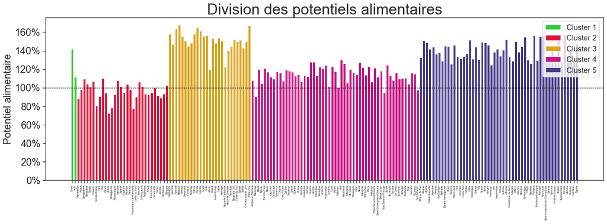

```python
figure = plt.figure(figsize=(20, 6))
axes = figure.add_subplot(111)

world_per("potentiel", axes)

axes.set_title("Division des potentiels alimentaires", fontsize=30)
axes.set_ylabel("Potentiel alimentaire", fontsize=20)
plt.yticks(fontsize=20)
plt.show()
```

## *II.4. Inégalités économiques*

Il n'est pas surprenant de mettre en avant les inégalités économiques pour expliquer pourquoi certains pays souffrent encore aujourd'hui de sous-nutrition, et d'autres non. Ce graphique résume ces inégalités selon les clusters.

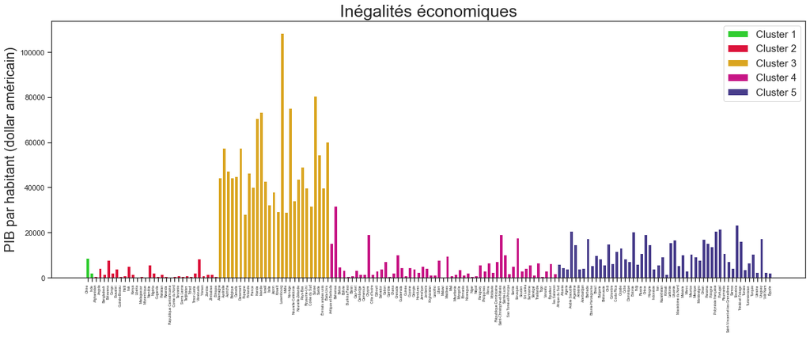

```python
dim(20, 7)
world_bar("pib_hbt")
plt.title("Inégalités économiques", fontsize=25)
plt.ylabel("PIB par habitant (dollar américain)", fontsize=20)
plt.show()
```

# III. Observations approfondies

## *III.1. Besoins alimentaires*

Divisons maintenant les besoins en protéines et en calories. **Notons tout d'abord que seuls les clusters 2 et 4 admettent des pays dont le potentiel alimentaire est inférieur à 100%.** C'est pourquoi nous allons, pour le moment, ne classifier les besoins en calories et en protéines que pour les pays de ces deux clusters.

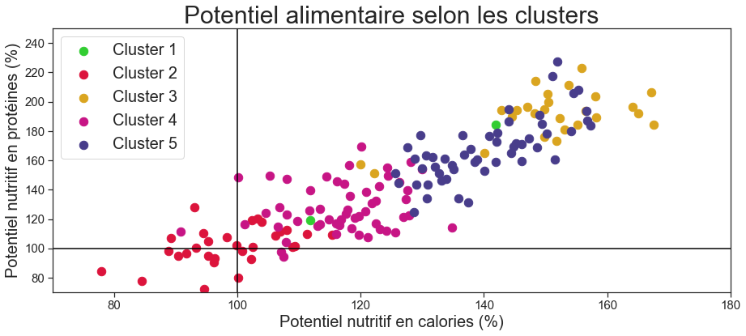

```python
fig, ax = plt.subplots(figsize=(15, 6))

plt.axhline(100, color="black") ; plt.axvline(100, color="black")

k=1
for data in [w1, w2, w3, w4, w5]:
    data.plot.scatter(ax=ax, x="potentiel_calorie", y="potentiel_proteine",
                      s=110, color=palette[k-1], label="Cluster %s" %k)
    k+=1

plt.title("Potentiel alimentaire selon les clusters", fontsize=30)
plt.xlabel("Potentiel nutritif en calories (%)", fontsize=20)
plt.ylabel("Potentiel nutritif en protéines (%)", fontsize=20)
plt.xticks(fontsize=15) ; plt.yticks(fontsize=15)
plt.legend(loc="upper left", fontsize=20)
plt.xlim(70, 180)
plt.ylim(70, 250)
plt.show()
```

Remarquons tout d'abord que les pays ayant un potentiel alimentaire insuffisant pour chacune des deux unités d'énergie (calories et protéines) sont tous des pays du cluster 2. Ce cluster comprend donc bel et bien les pays dont l'aide alimentaire est la plus urgente. Les pays du cluster 4 ne souffrent que d'une seule de ces deux insuffisances, si ce n'est d'aucune à défaut d'une certaine fragilité. Pour les clusters restants, nous ne relevons pas de distinction particulière entre calories et protéines pour ce qui est de leurs éventuels besoins alimentaires.

## *III.2. L'Inde et la Chine*

Lors du clustering, deux états se sont distingués du reste du monde de par la taille de leur population: l'Inde et la Chine. Ils forment à eux seuls le cluster 1 et nous consacrerons cette partie à l'étude des données récoltées pour ces deux pays.

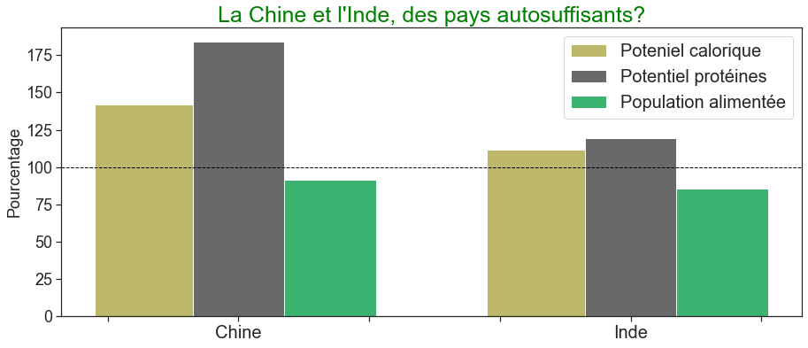

```python
dim(15, 6)

plt.axhline(100, linestyle="--", color="black", linewidth=1)

plt.bar(0.3, w1.loc["Chine", "potentiel_calorie"], color="darkkhaki", label="Poteniel calorique")
plt.bar(1, w1.loc["Chine", "potentiel_proteine"], width=0.7, color="dimgrey", label="Potentiel protéines")
plt.bar(1.7, 100-w1.loc["Chine", "und_percentage"], width=0.7, color="mediumseagreen", label="Population alimentée")

plt.legend(loc="upper right", fontsize=20)

plt.bar(3.3, w1.loc["Inde", "potentiel_calorie"], color="darkkhaki", label="Poteniel calorique")
plt.bar(4, w1.loc["Inde", "potentiel_proteine"], width=0.7, color="dimgrey", label="Potentiel protéines")
plt.bar(4.7, 100-w1.loc["Inde", "und_percentage"], width=0.7, color="mediumseagreen", label="Population alimentée")

plt.yticks(fontsize=18) ; plt.ylabel("Pourcentage", fontsize=18)
plt.xticks(range(0, 6), ["", "Chine", "", "", "Inde", ""], fontsize=20)
plt.title("La Chine et l'Inde, des pays autosuffisants?", fontsize=25, color="green")
plt.grid(False)
plt.show()
```